# PracticalLab2

## Practical Lab 2 - Multivariate Linear Regression, Non-Parametric Models and Cross-Validation

- Name : Khushbu Lad - 9027375
- Prof : Ran Feldesh
- Due date: 13th Oct,24

### Configure and load diabitish dataset

```python
import numpy as np
import pandas as pd
import sklearn.datasets
import matplotlib.pyplot as plt
from sklearn.model_selection import train_test_split
from sklearn.preprocessing import PolynomialFeatures
from sklearn.linear_model import LinearRegression
from sklearn.metrics import mean_absolute_error, r2_score
from sklearn.neighbors import KNeighborsRegressor
```

```python
# Understand data and target using return_x_y
data, target = sklearn.datasets.load_diabetes(return_X_y=True,as_frame=True)
```

```python
# Understand output : data
print(data)
```

```
          age       sex       bmi        bp        s1        s2        s3  \
0    0.038076  0.050680  0.061696  0.021872 -0.044223 -0.034821 -0.043401
1   -0.001882 -0.044642 -0.051474 -0.026328 -0.008449 -0.019163  0.074412
2    0.085299  0.050680  0.044451 -0.005670 -0.045599 -0.034194 -0.032356
3   -0.089063 -0.044642 -0.011595 -0.036656  0.012191  0.024991 -0.036038
4    0.005383 -0.044642 -0.036385  0.021872  0.003935  0.015596  0.008142
..        ...       ...       ...       ...       ...       ...       ...
437  0.041708  0.050680  0.019662  0.059744 -0.005697 -0.002566 -0.028674
438 -0.005515  0.050680 -0.015906 -0.067642  0.049341  0.079165 -0.028674
439  0.041708  0.050680 -0.015906  0.017293 -0.037344 -0.013840 -0.024993
440 -0.045472 -0.044642  0.039062  0.001215  0.016318  0.015283 -0.028674
441 -0.045472 -0.044642 -0.073030 -0.081413  0.083740  0.027809  0.173816

           s4        s5        s6
0   -0.002592  0.019907 -0.017646
1   -0.039493 -0.068332 -0.092204
2   -0.002592  0.002861 -0.025930
3    0.034309  0.022688 -0.009362
4   -0.002592 -0.031988 -0.046641
..        ...       ...       ...
437 -0.002592  0.031193  0.007207
438  0.034309 -0.018114  0.044485
439 -0.011080 -0.046883  0.015491
440  0.026560  0.044529 -0.025930
441 -0.039493 -0.004222  0.003064

[442 rows x 10 columns]
```

```python
# Understand output : target
print(target)
```

```
0      151.0
1       75.0
2      141.0
3      206.0
4      135.0
       ...
437    178.0
438    104.0
439    132.0
440    220.0
441     57.0
Name: target, Length: 442, dtype: float64
```

### Problem Statement

The objective of this notebook is to use diabetes dataset consisiting data of various parameters, and predict its progression one year after baseline. To predict this, historical data available will be considered.

### Explore Data

```python
data.describe()
```

|  | age | sex | bmi | bp | s1 | s2 | s3 | s4 | s5 | s6 |
| --- | --- | --- | --- | --- | --- | --- | --- | --- | --- | --- |
| count | 4.420000e+02 | 4.420000e+02 | 4.420000e+02 | 4.420000e+02 | 4.420000e+02 | 4.420000e+02 | 4.420000e+02 | 4.420000e+02 | 4.420000e+02 | 4.420000e+02 |
| mean | -2.511817e-19 | 1.230790e-17 | -2.245564e-16 | -4.797570e-17 | -1.381499e-17 | 3.918434e-17 | -5.777179e-18 | -9.042540e-18 | 9.293722e-17 | 1.130318e-17 |
| std | 4.761905e-02 | 4.761905e-02 | 4.761905e-02 | 4.761905e-02 | 4.761905e-02 | 4.761905e-02 | 4.761905e-02 | 4.761905e-02 | 4.761905e-02 | 4.761905e-02 |
| min | -1.072256e-01 | -4.464164e-02 | -9.027530e-02 | -1.123988e-01 | -1.267807e-01 | -1.156131e-01 | -1.023071e-01 | -7.639450e-02 | -1.260971e-01 | -1.377672e-01 |
| 25% | -3.729927e-02 | -4.464164e-02 | -3.422907e-02 | -3.665608e-02 | -3.424784e-02 | -3.035840e-02 | -3.511716e-02 | -3.949338e-02 | -3.324559e-02 | -3.317903e-02 |
| 50% | 5.383060e-03 | -4.464164e-02 | -7.283766e-03 | -5.670422e-03 | -4.320866e-03 | -3.819065e-03 | -6.584468e-03 | -2.592262e-03 | -1.947171e-03 | -1.077698e-03 |
| 75% | 3.807591e-02 | 5.068012e-02 | 3.124802e-02 | 3.564379e-02 | 2.835801e-02 | 2.984439e-02 | 2.931150e-02 | 3.430886e-02 | 3.243232e-02 | 2.791705e-02 |
| max | 1.107267e-01 | 5.068012e-02 | 1.705552e-01 | 1.320436e-01 | 1.539137e-01 | 1.987880e-01 | 1.811791e-01 | 1.852344e-01 | 1.335973e-01 | 1.356118e-01 |

#### Scatter plot for all columns

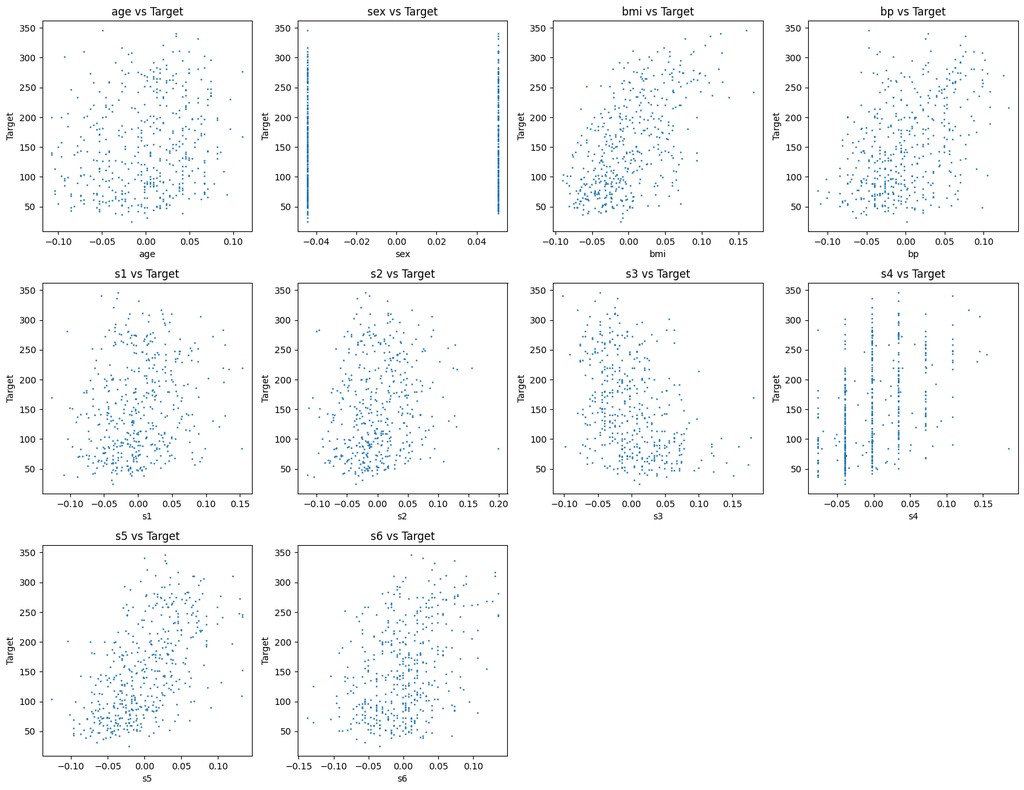

```python
fig, axes = plt.subplots(nrows=4, ncols=4, figsize=(16, 16))
axes = axes.flatten()
for i, column in enumerate(data.columns):
    axes[i].scatter(data[column], target,s=0.8)
    axes[i].set_title(f'{column} vs Target')
    axes[i].set_xlabel(column)
    axes[i].set_ylabel('Target')
for i in range(len(data.columns), len(axes)):
    axes[i].set_visible(False)
plt.tight_layout()
plt.show()
```

Whereas, **BMI shows strong relation** with target, i.e higher BMI tends to higher probability of diabetes progression. Similarly, **BP and S5** also indicates **positive corelation** with the target

#### Box plot for all coulmns

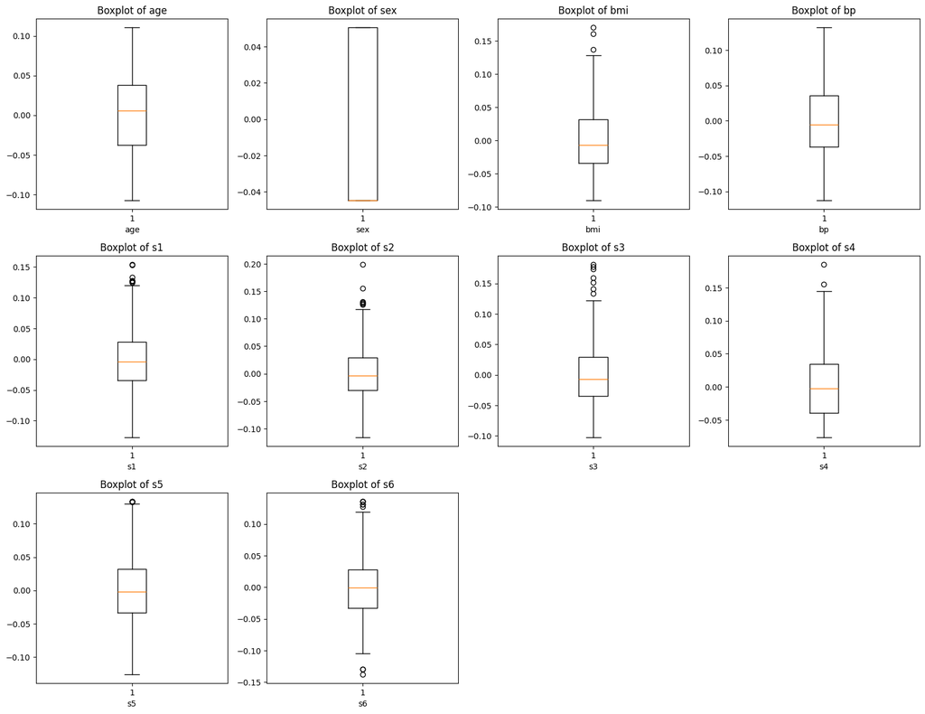

```python
fig, axes = plt.subplots(nrows=4, ncols=4, figsize=(16, 16))

axes = axes.flatten()

for i, column in enumerate(data.columns):
    axes[i].boxplot(data[column])
    axes[i].set_title(f'Boxplot of {column}')
    axes[i].set_xlabel(column)

for i in range(len(data.columns), len(axes)):
    axes[i].set_visible(False)

plt.tight_layout()
plt.show()
```

Observing box plot for all parameters, Most of the parameters shows outliers, but does now give clear insights related to it.

### Split and train dataset

Split the dataset to a train (75%) and validation set (10%), and test set (15%).

```python
# Split the dataset into train (75%) and temp (25%) >> this 25% will further destrubuted for validation and test
X_train, X_temp, y_train, y_temp = train_test_split(data, target, test_size=0.25, random_state=42)
# divide temp data into validate and
X_val, X_test, y_val, y_test = train_test_split(X_temp, y_temp, test_size=0.6, random_state=42)

print(f'Train set size \t\t: {X_train.shape[0]}')
print(f'Validation set size\t: {X_val.shape[0]}')
print(f'Test set size\t\t: {X_test.shape[0]}')
```

```
Train set size 		: 331
Validation set size	: 44
Test set size		: 67
```

### Polynomial regression : BMI vs Target

#### For degree 1 to 5

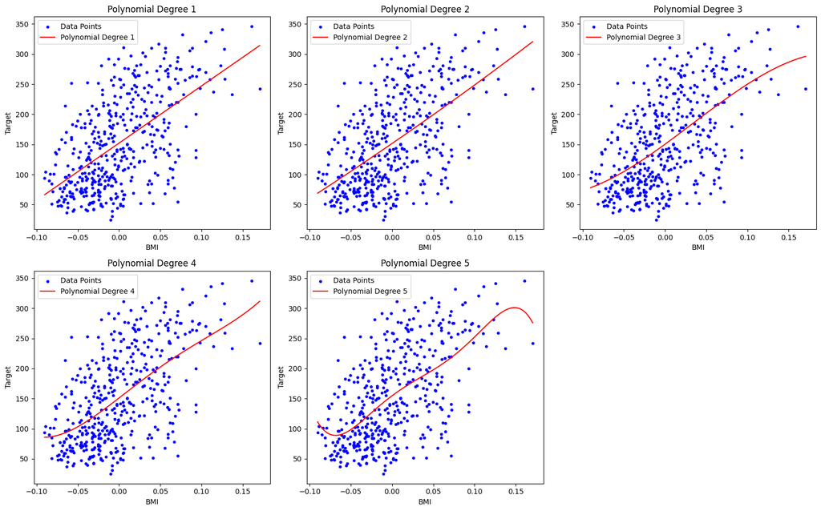

```python
X = data[['bmi']].values
y = target.values

plt.figure(figsize=(16, 10))

metrics = []

for degree in range(1, 6):
    # Create polynomial features
    poly = PolynomialFeatures(degree=degree)
    X_poly = poly.fit_transform(X)

    # Fit the model
    model = LinearRegression()
    model.fit(X_poly, y)

    # Generate predictions for plotting
    X_plot = np.linspace(X.min(), X.max(), 100).reshape(-1, 1)
    X_plot_poly = poly.transform(X_plot)
    y_pred = model.predict(X_plot_poly)

    # Plot the results
    plt.subplot(2, 3, degree)
    plt.scatter(X, y, color='blue', s=10, label='Data Points')
    plt.plot(X_plot, y_pred, color='red', label=f'Polynomial Degree {degree}')
    plt.title(f'Polynomial Degree {degree}')
    plt.xlabel('BMI')
    plt.ylabel('Target')
    plt.legend()

    # Calculate mae, mape, rsquad
    r_squared = r2_score(y, model.predict(X_poly))
    mae = mean_absolute_error(y, model.predict(X_poly))
    mape = np.mean(np.abs((y - model.predict(X_poly)) / y)) * 100
    equation = 'y = ' + ' + '.join([f'{coef:.2f}x^{i}' for i, coef in enumerate(model.coef_)])

    # Store metrics
    metrics.append((degree, r_squared, mae, mape,equation))

plt.tight_layout()
plt.show()
```

#### Print metrices

```python
print("Metrics for Polynomial Regression Models:")
print()
print("Degree | R-Squared \t| MAE \t\t| MAPE (%) \t| Equation")
print()
for degree, r_squared, mae, mape,equation in metrics:
    print(f"{degree:<6} | {r_squared:.4f} \t| {mae:.4f} \t| {mape:.2f} \t| {equation:}")
```

```
Metrics for Polynomial Regression Models:

Degree | R-Squared 	| MAE 		| MAPE (%) 	| Equation

1      | 0.3439 	| 51.7986 	| 47.69 	| y = 0.00x^0 + 949.44x^1
2      | 0.3441 	| 51.7790 	| 47.66 	| y = 0.00x^0 + 941.15x^1 + 292.30x^2
3      | 0.3451 	| 51.5730 	| 47.42 	| y = 0.00x^0 + 998.04x^1 + 1151.10x^2 + -11656.81x^3
4      | 0.3456 	| 51.5196 	| 47.30 	| y = 0.00x^0 + 1055.27x^1 + 412.55x^2 + -25895.12x^3 + 114576.32x^4
5      | 0.3494 	| 51.3153 	| 47.09 	| y = 0.00x^0 + 1020.80x^1 + -4912.86x^2 + 674.46x^3 + 914675.81x^4 + -4761817.10x^5
```

#### Equation : y = 998.04x + 1151.10x<sup>2</sup> + -11656.81x<sup>3</sup>

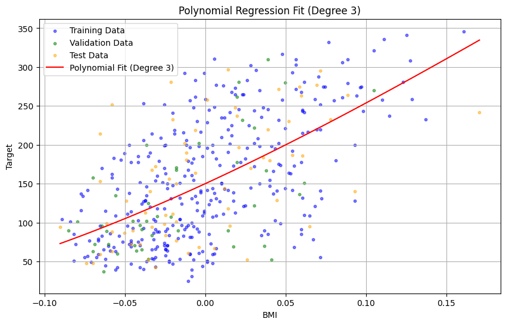

```python
X = data[['bmi']].values
y = target.values

# Split the dataset into train (75%), validation (10%), and test (15%)
X_train, X_temp, y_train, y_temp = train_test_split(X, y, test_size=0.25, random_state=42)
X_val, X_test, y_val, y_test = train_test_split(X_temp, y_temp, test_size=0.6, random_state=42)

# Fit polynomial regression model for degree 3
degree = 3
poly = PolynomialFeatures(degree=degree)
X_train_poly = poly.fit_transform(X_train)
X_val_poly = poly.transform(X_val)
X_test_poly = poly.transform(X_test)

# Fit the model
model = LinearRegression()
model.fit(X_train_poly, y_train)

# Generate predictions
y_train_pred = model.predict(X_train_poly)
y_val_pred = model.predict(X_val_poly)
y_test_pred = model.predict(X_test_poly)

# Create a range of x values for plotting the polynomial fit
X_plot = np.linspace(X.min(), X.max(), 100).reshape(-1, 1)
X_plot_poly = poly.transform(X_plot)
y_plot_pred = model.predict(X_plot_poly)

# Create a plot
plt.figure(figsize=(10, 6))

# Plot training data
plt.scatter(X_train, y_train, color='blue', s=10, label='Training Data', alpha=0.5)
# Plot validation data
plt.scatter(X_val, y_val, color='green', s=10, label='Validation Data', alpha=0.5)
# Plot test data
plt.scatter(X_test, y_test, color='orange', s=10, label='Test Data', alpha=0.5)

# Plot the polynomial fit
plt.plot(X_plot, y_plot_pred, color='red', label=f'Polynomial Fit (Degree {degree})')

# Add labels and title
plt.title(f'Polynomial Regression Fit (Degree {degree})')
plt.xlabel('BMI')
plt.ylabel('Target')
plt.legend()
plt.grid(True)

plt.show()
```

#### Predictions for best fit model

```python
predicted_progression = model.predict(poly.transform(np.array([[0.3],[0.5],[0.7]])))
print(f"Expected diabetes progression for a BMI value of 0.3: {predicted_progression[0]}")
print(f"Expected diabetes progression for a BMI value of 0.5: {predicted_progression[1]}")
print(f"Expected diabetes progression for a BMI value of 0.7: {predicted_progression[2]}")
```

```
Expected diabetes progression for a BMI value of 0.3: 489.76418714799274
Expected diabetes progression for a BMI value of 0.5: 712.473725319568
Expected diabetes progression for a BMI value of 0.7: 860.848705257167
```

#### Trainable Parameters

```python
feature_names = poly.get_feature_names_out(input_features=['bmi'])
num_parameters = len(feature_names)
print(f"Polynomial Features: {feature_names}")
print(f"Number of Trainable Parameters: {num_parameters}")
```

```
Polynomial Features: ['1' 'bmi' 'bmi^2' 'bmi^3']
Number of Trainable Parameters: 4
```

#### Conclusion

Selected model with degree 3 shows efficient relationship between BMI and diabetes progression as validation and test data plotting are within the range, so it can predict accurate values in these complex metrices. Polynomial with higher degrees might seems overfitted to data

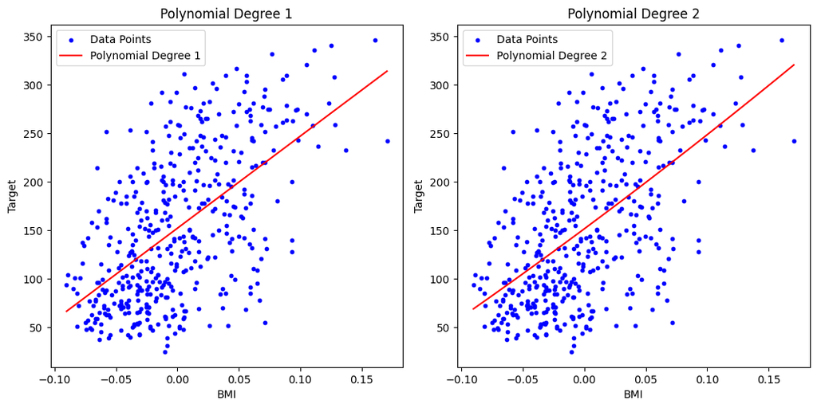

```python
X = data[['bmi']].values
y = target.values

plt.figure(figsize=(16, 10))

metrics = []

for degree in range(1, 3):
    # Create polynomial features
    poly = PolynomialFeatures(degree=degree)
    X_poly = poly.fit_transform(X)

    # Fit the model
    model = LinearRegression()
    model.fit(X_poly, y)

    # Generate predictions for plotting
    X_plot = np.linspace(X.min(), X.max(), 100).reshape(-1, 1)
    X_plot_poly = poly.transform(X_plot)
    y_pred = model.predict(X_plot_poly)

    # Plot the results
    plt.subplot(2, 3, degree)
    plt.scatter(X, y, color='blue', s=10, label='Data Points')
    plt.plot(X_plot, y_pred, color='red', label=f'Polynomial Degree {degree}')
    plt.title(f'Polynomial Degree {degree}')
    plt.xlabel('BMI')
    plt.ylabel('Target')
    plt.legend()

    # Calculate mae, mape, rsquad
    r_squared = r2_score(y, model.predict(X_poly))
    mae = mean_absolute_error(y, model.predict(X_poly))
    mape = np.mean(np.abs((y - model.predict(X_poly)) / y)) * 100
    equation = 'y = ' + ' + '.join([f'{coef:.2f}x^{i}' for i, coef in enumerate(model.coef_)])

    # Store metrics
    metrics.append((degree, r_squared, mae, mape,equation))

plt.tight_layout()
plt.show()
```

```python
print("Metrics for Polynomial Regression Models:")
print()
print("Degree | R-Squared \t| MAE \t\t| MAPE (%) \t| Equation")
print()
for degree, r_squared, mae, mape,equation in metrics:
    print(f"{degree:<6} | {r_squared:.4f} \t| {mae:.4f} \t| {mape:.2f} \t| {equation:}")
```

```
Metrics for Polynomial Regression Models:

Degree | R-Squared 	| MAE 		| MAPE (%) 	| Equation

1      | 0.3439 	| 51.7986 	| 47.69 	| y = 0.00x^0 + 949.44x^1
2      | 0.3441 	| 51.7790 	| 47.66 	| y = 0.00x^0 + 941.15x^1 + 292.30x^2
```

### KNN with K=3

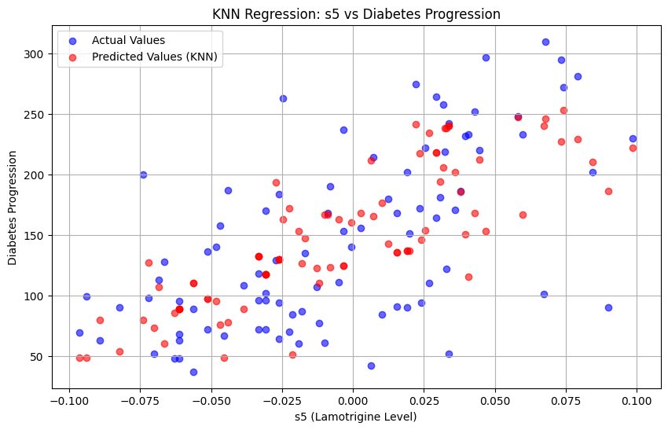

```
r_squared 	 : 0.20288670154408806
mae 	 : 51.449438202247194
mape 	 : 49.60404692259969
```

```python
X = data[['s5']].values
y = target.values
X_train, X_test, y_train, y_test = train_test_split(X, y, test_size=0.2, random_state=42)

knn = KNeighborsRegressor(n_neighbors=3)
knn.fit(X_train, y_train)
y_pred = knn.predict(X_test)

plt.figure(figsize=(10, 6))
plt.scatter(X_test, y_test, color='blue', label='Actual Values', alpha=0.6)
plt.scatter(X_test, y_pred, color='red', label='Predicted Values (KNN)', alpha=0.6)

plt.xlabel('s5 (Lamotrigine Level)')
plt.ylabel('Diabetes Progression')
plt.title('KNN Regression: s5 vs Diabetes Progression')
plt.legend()
plt.grid(True)
plt.show()

r_squared = r2_score(y_test, y_pred)
mae = mean_absolute_error(y_test, y_pred)
mape = np.mean(np.abs((y_test - y_pred) / y_test)) * 100

print(f"r_squared \t : {r_squared}")
print(f"mae \t : {mae}")
print(f"mape \t : {mape}")
```

### KNN with K=5

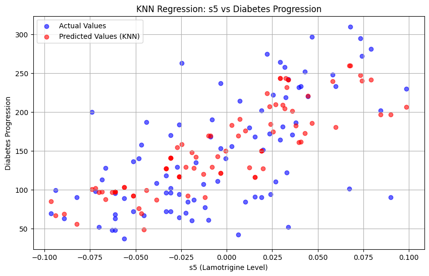

```
r_squared 	 : 0.3069993752183279
mae 	 : 48.0629213483146
mape 	 : 46.783929402442006
```

```python
X = data[['s5']].values
y = target.values
X_train, X_test, y_train, y_test = train_test_split(X, y, test_size=0.2, random_state=42)

knn = KNeighborsRegressor(n_neighbors=5)
knn.fit(X_train, y_train)
y_pred = knn.predict(X_test)

plt.figure(figsize=(10, 6))
plt.scatter(X_test, y_test, color='blue', label='Actual Values', alpha=0.6)
plt.scatter(X_test, y_pred, color='red', label='Predicted Values (KNN)', alpha=0.6)

plt.xlabel('s5 (Lamotrigine Level)')
plt.ylabel('Diabetes Progression')
plt.title('KNN Regression: s5 vs Diabetes Progression')
plt.legend()
plt.grid(True)
plt.show()

r_squared = r2_score(y_test, y_pred)
mae = mean_absolute_error(y_test, y_pred)
mape = np.mean(np.abs((y_test - y_pred) / y_test)) * 100

print(f"r_squared \t : {r_squared}")
print(f"mae \t : {mae}")
print(f"mape \t : {mape}")
```

#### Conclusion - KNN Plotting

As per MAE (more accurate in terms of absolute error), MAPE ( more accurate predictions) and R-Squard ( more variance) : **K=5 outperforms than K=3**

### Decision tree : Depth = 2

[figure not shown]

```
[Text(0.5, 0.8333333333333334, 'x[0] <= -0.004\nsquared_error = 5929.885\nsamples = 442\nvalue = 152.133'),
```

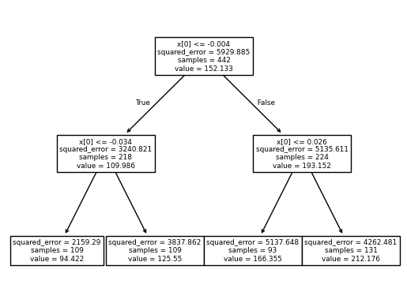

```python
from sklearn import tree

X = data[['s5']].values
y = target.values
model = tree.DecisionTreeRegressor(max_depth=2)
model = model.fit(X, y)
plt.scatter(X, y, c="orange")
tree_x = np.linspace(min(X), max(X), 1000).reshape(-1,1)

plt.plot(tree_x, model.predict(tree_x), c="black")

# add labels
plt.xlabel("BMI")
plt.ylabel("Disease Progression")
plt.title("Decision Tree Regression")

plt.show()

tree.plot_tree(model)
```

### Decision tree : Depth = 3

[figure not shown]

```
[Text(0.5, 0.875, 'x[0] <= -0.004\nsquared_error = 5929.885\nsamples = 442\nvalue = 152.133'),
```

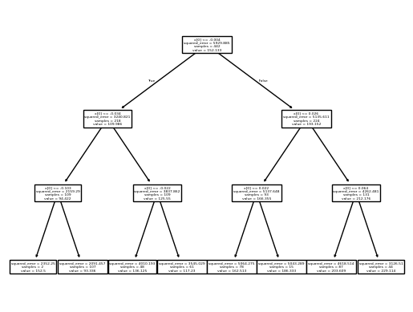

```python
X = data[['s5']].values
y = target.values
model = tree.DecisionTreeRegressor(max_depth=3)
model = model.fit(X, y)
plt.scatter(X, y, c="orange")
tree_x = np.linspace(min(X), max(X), 1000).reshape(-1,1)

plt.plot(tree_x, model.predict(tree_x), c="black")

# add labels
plt.xlabel("BMI")
plt.ylabel("Disease Progression")
plt.title("Decision Tree Regression")
plt.show()

tree.plot_tree(model)
```

### Conclusion

As per Squard error, Decision tree with depth 3 is more accurate but considering plotting line, it is overfitted, Whereas, Depth=2 is more accurate in my opionion as it is giving less error in most dense poltting.